# PulmonDB - COVID19.

Monica Padilla

## **PCA between bronchealveolar immune cells (scRNA-seq) and SARS-CoV-2 infected A549, NHBE, Calu-3 cell lines and Lung samples (RNA-seq)**

Single cell and RNA seq data will be compared in the project. In order to know if the data is actually similar, I will explore it with PCA. Then, we can talk about the comparison of results (from single cell and bulk) provided the gene expression differences seen here.

### **Prepare terminal**

```bash
ssh -Y mpadilla@dna.liigh.unam.mx
screen -S pca
qlogin
cd /mnt/Citosina/amedina/mpadilla/COVID19/pca/
module unload r/3.2.1
module load r/4.0.2
umask 2
```

Some previous steps in the current report as well as code are in a previous report, see: `PCA-pseudobulk_n_bulkA549.*`.

### **Bulk study design**

When working with expression sequencing data, it is essential to know where data variation may come from. As well variation due to biological conditions, data can also variate due to batches, e.g. groups of sequencing runs.

The lines of code below just produces a file that specifies the study design (samples, release dates and experimental conditions).

- `/mnt/Citosina/amedina/mpadilla/COVID19/pca/data/studydesign_SC2-inf-celllines_Lung.csv`

Current dir = `/mnt/Citosina/amedina/mpadilla/COVID19/Data/`

Study design of all data[2]: `metadata/inter-files/dates_samples_experiments.tsv`

**Bulk data to be used:**

A549 cell line : adenocarcinomic human alveolar basal epithelial cells, model for alveolar Type II pulmonary epithelium (AT2) cell type [4] `pca/data/studydesign_date_mockA549.csv`

NHBE cell line :

Calu-3 cell line :

Lung biopsy/samples

**Subset for SARS-CoV-2 infected cell lines and COVID19 Lung sample with controls:**

Current dir = `/mnt/Citosina/amedina/mpadilla/COVID19/Data/`

```bash
echo 'release_dates,samples,experiments' > ../pca/data/studydesign_SC2-inf-celllines_Lung.csv
# SARS-CoV-2 infected samples
grep "SARS-CoV-2_infected_[ANC]" metadata/inter-files/dates_samples_experiments.tsv | perl -pe 's/\t/,/g'>> ../pca/data/studydesign_SC2-inf-celllines_Lung.csv
# Mock samples
grep "Mock_treated_[ANC]" metadata/inter-files/dates_samples_experiments.tsv | perl -pe 's/\t/,/g'>> ../pca/data/studydesign_SC2-inf-celllines_Lung.csv
# Lung samples
grep "Lung_" metadata/inter-files/dates_samples_experiments.tsv | perl -pe 's/\t/,/g'>> ../pca/data/studydesign_SC2-inf-celllines_Lung.csv
```

### **PCA of bulk samples**

This section includes:

- Join bulk samples in CLI
- Clean data
- Correct by batch effect
- PCA visualization

#### **Join bulk samples in CLI**

```bash
cat ../../pca/data/Lung_all-Mock_A549_all-SC2_inf_A549_all-counts.csv SARS-CoV-2_infected_Calu-3/SARS-CoV-2_infected_Calu-3-counts.csv SARS-CoV-2_infected_NHBE/SARS-CoV-2_infected_NHBE-counts.csv Mock_treated_Calu-3/Mock_treated_Calu-3-counts.csv Mock_treated_NHBE/Mock_treated_NHBE-counts.csv > ../../pca/data/SARS-CoV-2-inf-celllines_Lung-counts.csv
```

#### **Clean data**

```r
# Load merged data of SARS-CoV-2-inf-celllines and Lung experiments
bulk <- as.data.frame(read.csv("./data/SARS-CoV-2-inf-celllines_Lung-counts.csv", sep = ","))
dim(bulk) #  54 194361
# Load metadata
meta.bulk <- as.data.frame(read.csv("/mnt/Citosina/amedina/mpadilla/COVID19/pca/data/studydesign_SC2-inf-celllines_Lung.csv", sep = ","))


## Clean data
bulk <- column_to_rownames(bulk, var = "samples")
bulk <- bulk[,which(apply(bulk,2,var) != 0)] # taking off genes that were not expressed
# dim(bulk)
#    54 174791
bulk <- t(bulk)

meta.bulk <- meta.bulk[match(colnames(bulk), meta.bulk$samples),] # put meta in the same order as counts matrix

head(bulk)[,1:5]
```

#### **Batch correction**

**Define batches and run combat-seq**

```r
# Define batches (in this case by date)
dates <- unique(meta.bulk$release_dates)
batch <- meta.bulk$release_dates
for (i in 1:length(dates)) {
  batch <- str_replace(batch, dates[i], paste0(i))
  i = i + 1
}
batch <- as.numeric(batch)
# Define biological conditions
exprmts <- rev(unique(meta.bulk$experiments))
bio.cond <- meta.bulk$experiments
for (i in 1:length(exprmts)) {
  bio.cond <- str_replace(bio.cond, exprmts[i], paste0(i))
  i = i + 1
}
bio.cond <- as.numeric(bio.cond)

# Correction of batch effects with ComBat-seq
library(sva)
adj.cts.both <- ComBat_seq(bulk,
                           batch = batch,
                           group = bio.cond)
```

```
Found 4 batches
Using full model in ComBat-seq.
Adjusting for 10 covariate(s) or covariate level(s)
Estimating dispersions
Fitting the GLM model
Shrinkage off - using GLM estimates for parameters
Adjusting the data
```

Check created object

```r
class(adj.cts.both) # "matrix" "array"
adj.cts.both <- adj.cts.both[which(apply(adj.cts.both,1,var) != 0),] # quit counts that transform to 0
dim(adj.cts.both) # 174791     54
object.size(adj.cts.both)/1e6 # 87.4 MB
```

*Note:* Object saved as and can be loaded as following.

```r
# write.csv(adj.cts.both, file = "data/SARS-CoV-2-inf-celllines_Lung-counts-adj.csv", quote = F)
```

#### **PCA Visualization**

Make dir for these plots:

```bash
mkdir plots_SC2-inf-celllines-Lung/
```

[figure not shown]

[figure not shown]

```r
## PCA
pca.bulk <- prcomp(t(as.data.frame(adj.cts.both)), scale = T)

# Create vector of experiment labels
experiments <- rep(
  c("Mock A549", "Mock A549 + ACE2", "SC2-inf-A549", "SC2-inf-A549 + ACE2",
    "SC2-inf-A549 + ACE2 + pt", "Lung healthy","Lung COVID19", "SC2-inf-Calu3",
    "SC2-inf-NHBE", "Mock Calu3", "Mock NHBE"),
  c(13, 6, 6, 6, 3, 2, 2, 3, 3, 3, 7))
SC2infected <- c(rep("No",19), rep("Yes",15), rep("No",2), rep("Yes",8), rep("No",10))

## add labels to pca obj
pca.bulk$x <- add_column(as.data.frame(pca.bulk$x), experiments)
pca.bulk$x <- add_column(as.data.frame(pca.bulk$x), SC2infected)

## axes titles PC % explained var
pc.axis <- function(PCnum){
  paste0("PC",PCnum," (",
         summary(pca.bulk)$importance[2,][PCnum]*100,
         "% explained var.)")
}

## ggplot2 col-SC2inf  shape -experiments
png(file = "./plots_SC2-inf-celllines-Lung/pca_SARS-CoV-2-inf-celllines_Lung_adj_PC34_colSC2_gg2.png", width = 800, height = 800)
ggplot(pca.bulk$x, aes(x=PC3, y=PC4, group=experiments)) +
  geom_point(size=4, aes(shape=experiments, color=SC2infected)) +
  stat_ellipse(aes(color=SC2infected)) + # draw ellipses on bulk experiments
  scale_shape_manual(values=c(17,2,1,13,9,0,19,16,20,18,15)) +
  scale_color_manual(values = c("#af8dc3", "#7fbf7b")) + #purple and green
  labs(x = pc.axis(3), y = pc.axis(4))
dev.off()
```

**Conclusion**

### **PCA pseudo-bulk + bulk**

This section includes:

- Load data
- Join all data
- Batch correction
- PCA Visualization

#### **Load data**

- Bulk data experiments:
  - “Mock_treated_A549”
  - “Mock_treated_A549_w_vector_expressing_hACE2”
  - “SARS-CoV-2_infected_A549”
  - “SARS-CoV-2_infected_A549_w_vector_expressing_hACE2”
  - “SARS-CoV-2_infected_A549_w_vector_expressing_hACE2_1hr_Ruxolitinib_pre-treatment”
  - “Lung_biopsy_for_heatly_negative_control”
  - “Lung_sample_from_postmortem_COVID-19_patient”
  - “SARS-CoV-2_infected_Calu-3”
  - “SARS-CoV-2_infected_NHBE”
  - “Mock_treated_Calu-3”
  - “Mock_treated_NHBE”

See: **PCA in bulk** section.

- Normalized pseudo-bulk data:

```r
# Load pseudo-bulk tpm counts
tpm.counts <- as.data.frame(read.csv("./data/psbulk-tpm-counts.csv", sep = ","))
tpm.counts <- column_to_rownames(tpm.counts, "X")
```

#### **Join all data**

```r
## Join bulk and sc data
tpm.counts <- t(tpm.counts) # tpm.counts is now rows genes, cols cell types
tpm.counts.g <- rownames_to_column(as.data.frame(tpm.counts), var = "genes") # to use it in full_join
bulk.g <- rownames_to_column(as.data.frame(bulk), var = "genes")
bulk.g <- as.data.frame(bulk.g)
tpm.counts.g <- as.data.frame(tpm.counts.g)
merged.data <- full_join(bulk.g, tpm.counts.g, by = "genes")
merged.data <- column_to_rownames(merged.data, var = "genes")
merged.data <- as.data.frame(merged.data) # 182029     64
merged.data[is.na(merged.data)] <- 0

# head(merged.data)
```

*Note:* This object was saved at `pca/data/` and can be load like this:

```r
# write.csv(merged.data, file = "./data/SARS-CoV-2-inf-celllines_Lung-psbulk-merged_data.csv", quote = FALSE)
# merged data psbulk and bulk
merged.data <- as.data.frame(read.csv("./data/SARS-CoV-2-inf-celllines_Lung-psbulk-merged_data.csv", sep = ","))
merged.data <- column_to_rownames(merged.data, var = "genes")
```

#### **Batch correction**

In this case, batches are the 4 sequencing groups from bulk + 1 batch of single cell. Experimental conditions is not included in model because the group from single cell is the same as its batch.

```r
## Correct batch effects
batch <- c(batch, rep(5,10))
merged.data <- as.matrix(merged.data) # convert to matrix to avoid error (combat returning list instead of matrix)
adj.cts.all <- ComBat_seq(merged.data, batch = batch)
```

```
Found 5 batches
Using null model in ComBat-seq.
Adjusting for 0 covariate(s) or covariate level(s)
Estimating dispersions
Fitting the GLM model
Shrinkage off - using GLM estimates for parameters
Adjusting the data
```

Check object created:

```r
object.size(adj.cts.all)/1e6 # 105.6 MB
dim(adj.cts.all) # 182029     64
class(adj.cts.all) # "matrix" "array"
```

*Note:* This object was saved at `pca/data/` and can be load like this:

```r
# save to file
# write.csv(as.matrix(adj.cts.all), file = "./data/SARS-CoV-2-inf-celllines_Lung-psbulk-merged_data-adj.csv", quote = FALSE)
adj.cts.all <- as.data.frame(read.csv("./data/SARS-CoV-2-inf-celllines_Lung-psbulk-merged_data-adj.csv", sep = ",", quote = ""))
rownames(adj.cts.all) <- adj.cts.all$X
adj.cts.all <- as.matrix(adj.cts.all[,-1])
class(adj.cts.all) # matrix array
```

#### **PCA Visualization**

##### **PCA without batch correction**

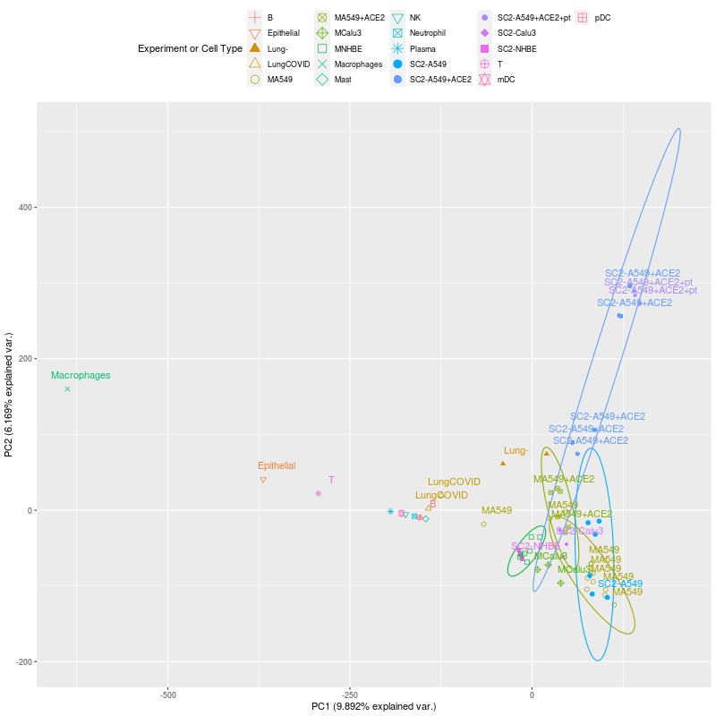

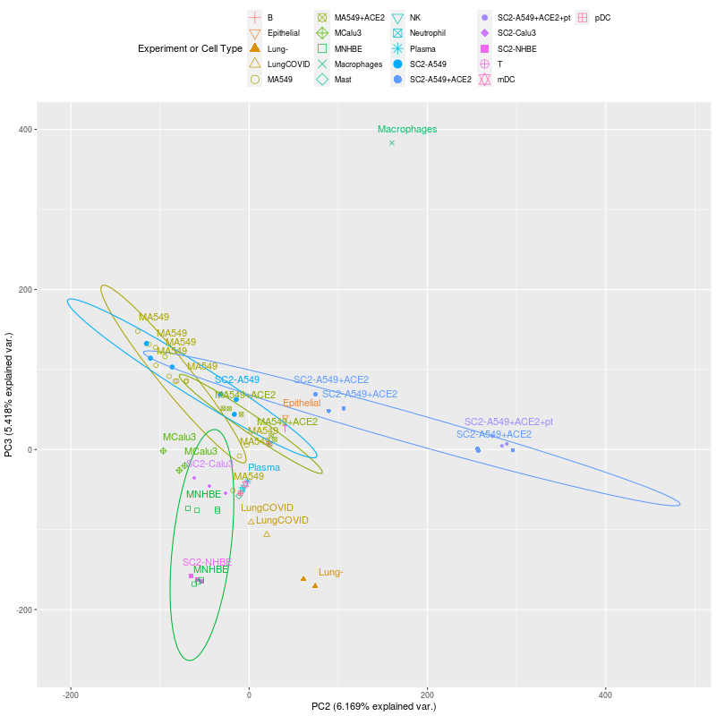

```r
## labels
experiments <- rep(
  c("MA549", "MA549+ACE2", "SC2-A549", "SC2-A549+ACE2", "SC2-A549+ACE2+pt",
    "Lung-","LungCOVID", "SC2-Calu3", "SC2-NHBE", "MCalu3", "MNHBE"),
  c(13, 6, 6, 6, 3, 2, 2, 3, 3, 3, 7))
experiments <- c(experiments, str_subset(colnames(merged.data),"^GSM", negate = T)) # add cell types

## PCA
pca.all <- prcomp(t(merged.data), scale = TRUE)

## add labels to pca obj
pca.all$x <- add_column(as.data.frame(pca.all$x), experiments)

## axes titles PC % explained var
pc.axis <- function(PCnum){
  paste0("PC",PCnum," (",
         summary(pca.all)$importance[2,][PCnum]*100,
         "% explained var.)")
}

## ggplot pca png -colexp, label some
png(file = "./plots_SC2-inf-celllines-Lung/pca_SARS-CoV-2-inf-celllines_Lung_psebulk_noadj_PC23_labels_gg2.png",
    width = 800, height = 800)
ggplot(pca.all$x, aes(x=PC2, y=PC3, shape=experiments, colour=experiments)) +
  geom_point(size=2) +
  scale_shape_manual(name = "Experiment or Cell Type",
                     values=c(3,25,17,2,1,13,9,0,4:8,19,16,20,18,15,10:12)) +
  stat_ellipse(aes(color=experiments), show.legend = F) +
  geom_text( aes(label=experiments, color=experiments),
             nudge_x = 18, nudge_y = 18, check_overlap = T, show.legend = F) +
  labs(x = pc.axis(2), y = pc.axis(3)) +
  theme(legend.position = "top") +
  guides(colour = guide_legend(override.aes = list(size=4))) +
  scale_colour_discrete(name="Experiment or Cell Type")
dev.off()
```

##### **PCA with batch correction**

```r
## PCA
pca.all <- prcomp(t(adj.cts.all), scale = TRUE)

## labels
experiments <- rep(
  c("MA549", "MA549+ACE2", "SC2-A549", "SC2-A549+ACE2", "SC2-A549+ACE2+pt",
    "Lung-","LungCOVID", "SC2-Calu3", "SC2-NHBE", "MCalu3", "MNHBE"),
  c(13, 6, 6, 6, 3, 2, 2, 3, 3, 3, 7))
experiments <- c(experiments, str_subset(colnames(adj.cts.all),"^GSM", negate = T)) # add cell types
epithelial <- c(rep("Yes", 34),rep("No",4),rep("Yes",16),"No","Yes", rep("No",8))

## add labels to pca obj
pca.all$x <- add_column(as.data.frame(pca.all$x), experiments)
pca.all$x <- add_column(as.data.frame(pca.all$x), epithelial)

## axes titles PC % explained var
pc.axis <- function(PCnum){
  paste0("PC",PCnum," (",
         summary(pca.all)$importance[2,][PCnum]*100,
         "% explained var.)")
}
```

**v1**

```r
## ggplot pca png -colexp, label some
png(file = "./plots_SC2-inf-celllines-Lung/pca_SARS-CoV-2-inf-celllines_Lung_psebulk_adj_PC12_labels_gg2.png",
    width = 800, height = 800)
ggplot(pca.all$x, aes(x=PC1, y=PC2, shape=experiments, colour=experiments)) +
  geom_point(size=2) +
  scale_shape_manual(name = "Experiment or Cell Type",
                     values=c(3,25,17,2,1,13,9,0,4:8,19,16,20,18,15,10:12)) +
  stat_ellipse(aes(color=experiments), show.legend = F) +
  geom_text( aes(label=experiments, color=experiments),
             nudge_x = 18, nudge_y = 18, check_overlap = T, show.legend = F) +
  labs(x = pc.axis(1), y = pc.axis(2)) +
  theme(legend.position = "top") +
  guides(colour = guide_legend(override.aes = list(size=4))) +
  scale_colour_discrete(name="Experiment or Cell Type")
dev.off()
```

**v2**

Color: epithelial Shape: experiments Label: Epithelial cell type

```r
## ggplot pca png
png(file = "./plots_SC2-inf-celllines-Lung/pca_SARS-CoV-2-inf-celllines_Lung_psebulk_adj_PC12_colepi_label_gg2.png",
    width = 800, height = 800)
ggplot(pca.all$x, aes(x=PC1, y=PC2, group=experiments)) +
  geom_point(size=3, aes(shape=experiments, color=epithelial)) +
  stat_ellipse(aes(color=epithelial), show.legend = F) + # draw ellipses on bulk experiments
  scale_shape_manual(name = "Experiment or Cell Type",
                     values=c(3,25,17,2,1,13,9,0,4:8,19,16,20,18,15,10:12)) +
  geom_label(
    data = pca.all$x %>% select(PC1,PC2,experiments, epithelial) %>% slice(56), # label only epithelial cell type
    aes(label=experiments, color=epithelial), nudge_x = 18, nudge_y = 18, show.legend = F) +
  labs(x = pc.axis(1), y = pc.axis(2)) +
  theme(legend.position = "top") +
  guides(colour = guide_legend(override.aes = list(size=4))) +
  scale_colour_discrete(name="Epithelial")
dev.off()
```

- **PC1&2**

**v1**

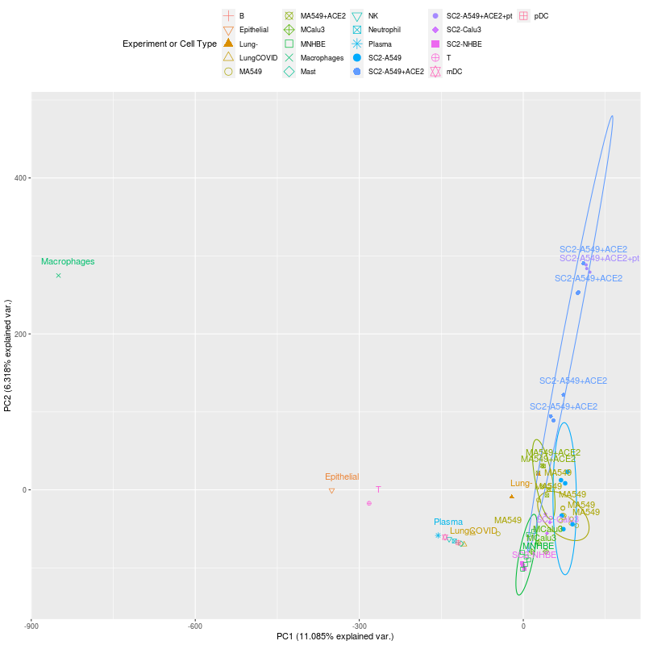

**v2**

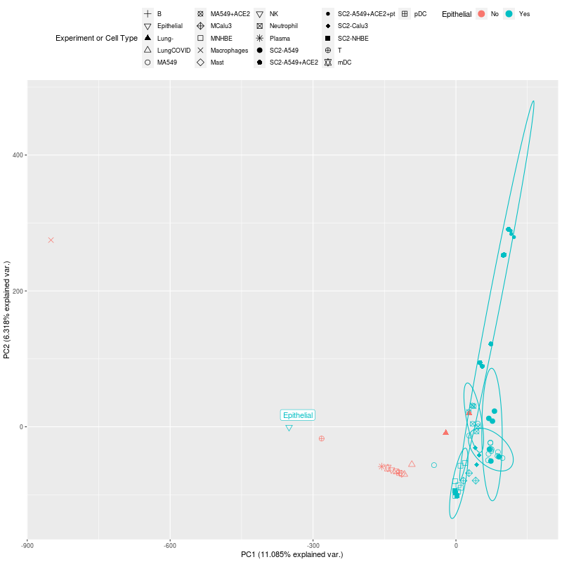

- **PC2&3**

**v1**

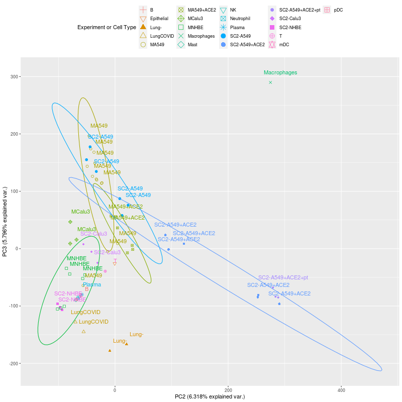

**v2**

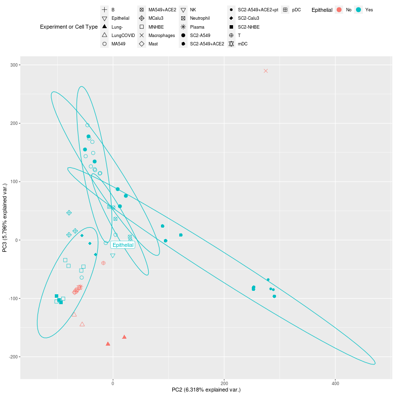

- **PC3&4**

**v1**

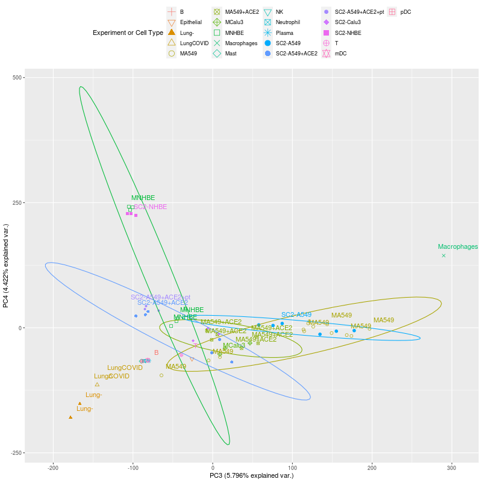

**v2**

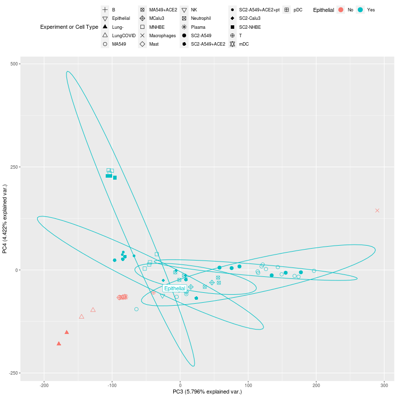

### **Conclusions**

**PCA of bulk samples: Mock treated and SARS-CoV-2 infected samples**

See below for notation*.

*Bulk notation:

- `Mock A549` or `Mk` : Mock treated A459 cell lines samples
- `Mock A549 + ACE2` or `Mk+ACE2` : Mock treated A459 cell lines with vector expression of ACE2 samples
- `SC2-inf-A549` or `SC2`: SARS-CoV-2 infected A459 cell lines samples
- `SC2-inf-A549 + ACE2` or `SC2+ACE2` : SARS-CoV-2 infected A459 cell lines with vector expression of ACE2 samples
- `SC2-inf-A549 + ACE2 + pt` or `SC2+ACE2+pt` : SARS-CoV-2 infected A459 cell lines with vector expression of ACE2 with 1hr Ruxolitinib pre-treatment (IFN-I signaling blocked) samples

**PCA of pseudo-bulk + all bulk data. Bronchoalveolar immune cell types + treated cell lines**

### **Refs**

In collaboration with Leonardo Arteaga, Ana Betty Villaseñor Altamirano, Karen Nuñez Reza and Alejandra Medina Rivera.

**References:**

[1] Liao, M., Liu, Y., Yuan, J., Wen, Y., Xu, G., Zhao, J., … & Zhang, Z. (2020). Single-cell landscape of bronchoalveolar immune cells in patients with COVID-19. Nature medicine, 26(6), 842-844.

[2] Blanco-Melo, D., Nilsson-Payant, B. E., Liu, W. C., Uhl, S., Hoagland, D., Møller, R., … & Albrecht, R. A. (2020). Imbalanced host response to SARS-CoV-2 drives development of COVID-19. Cell, 181(5), 1036-1045.

[3] Zhang, Y., Parmigiani, G., & Johnson, W. E. (2020). ComBat-seq: batch effect adjustment for RNA-seq count data. NAR genomics and bioinformatics, 2(3), lqaa078.

[4] Foster, K. A., Oster, C. G., Mayer, M. M., Avery, M. L., & Audus, K. L. (1998). Characterization of the A549 cell line as a type II pulmonary epithelial cell model for drug metabolism. Experimental cell research, 243(2), 359-366.

**Programs and versions:**

- R 4.0.2

  packages:
  - SingleCellExperiment
  - scuttle
  - Seurat
  - tidyverse
    - dplyr
    - stringr
    - ggplot2
  - biomaRt
  - ggbiplot
  - sva
    - ComBat-seq

*Last update: Oct 4th,2021*